# Población en situación de discapacidad

Diana Villasana Ocampo

## Los Derechos de las Personas con Discapacidad en México

Cuando se habla de los **Derechos de las Personas con Discapacidad en México**, es un tema que ha ido tomando relevancia desde el año 2011 con la promulgación de la **Ley General para la Inclusión de las Personas con Discapacidad**, que marcó un hito importante en el reconocimiento y protección de sus derechos. En diferentes contextos de derechos humanos, los temas en materia de género en México comenzaron a tomar relevancia significativa en el año 1974, con la reforma al Artículo 4° Constitucional que estableció la igualdad jurídica entre hombres y mujeres. Por su parte, los temas relacionados con los derechos de las personas indígenas y afrodescendientes en México empezaron a tomar mayor relevancia a partir de 1992, con el reconocimiento constitucional de la composición pluricultural de la nación, fortalecido posteriormente con la reforma constitucional de 2001 que reconoció los derechos de los pueblos indígenas. Este marco normativo emergente ha evidenciado la histórica marginación y falta de reconocimiento que estos grupos poblacionales han enfrentado.

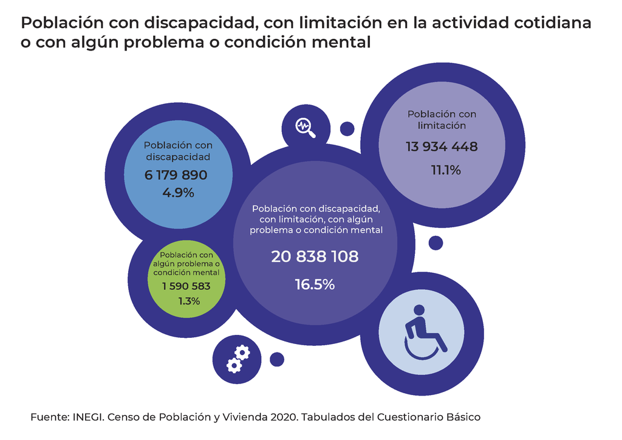

**Elaboración propia**

### Plan Nacional de Desarrollo 2019-2024

En México, hoy en día se ha considerado a la población con discapacidad como un grupo prioritario de atención según lo establecido en el **Plan Nacional de Desarrollo 2019-2024**, el cual marca un cambio significativo en el reconocimiento de sus derechos y necesidades. Este plan ha establecido directrices específicas y ha priorizado acciones concretas para garantizar que las personas con discapacidad puedan ejercer sus derechos de manera efectiva y participar plenamente en la sociedad. Asimismo, este grupo poblacional ha sido identificado como población objetivo de diversos programas sociales implementados por la **Secretaría de Bienestar**, lo cual demuestra un compromiso institucional con la inclusión y el bienestar de las personas con discapacidad en el país.

### Instrumentos en México

Existen diversos instrumentos aplicados en México que recopilan información sobre la población con discapacidad:

- **Censos Generales de Población y Vivienda (INEGI):**
  - Última actualización: 2020.
  - Incluye el Cuestionario del Grupo de Washington para una mejor identificación de la discapacidad.
- **Encuesta Nacional de Empleo y Seguridad Social (ENESS - INEGI):**
  - Última actualización: 2017.
- **Encuesta Nacional de Salud y Nutrición (ENSANUT):**
  - Última actualización: 2023.
- **Encuesta Nacional de Uso del Tiempo (ENUT - INEGI):**
  - Última actualización: 2024.
- **Encuesta Nacional de Ingresos y Gastos en los Hogares (ENIGH - INEGI):**
  - Última actualización: 2022.
- **Encuesta Nacional de la Dinámica Demográfica (ENADID - INEGI):**
  - Última actualización: 2023.
- **Encuesta Nacional de la Dinámica y las Relaciones en los Hogares (ENDIREH - INEGI):**
  - Última actualización: 2021.
- **Encuesta Nacional sobre Salud y Envejecimiento en México (ENASEM):**
  - Última actualización: 2021.

## Censo de Población y Vivienda 2020

El sistema censal mexicano ha experimentado una notable transformación desde sus inicios en 1895, cuando el INEGI comenzó a realizar estos ejercicios estadísticos. Lo que comenzó como un simple conteo poblacional que registraba datos básicos (número de habitantes, edad, sexo, estado civil y nivel de alfabetización) evolucionó significativamente entre 2000 y 2010. Durante este período, el censo amplió su alcance para incluir aspectos más complejos como las características de la vivienda, patrones de migración y condiciones económicas de la población. En 2002, se introdujo el enfoque de la **CIF** en la **Encuesta Nacional de Evaluación al Desempeño (`ENED`)**, incorporando preguntas para identificar la dificultad para realizar tareas (INEGI, 2017).

Un avance fundamental en esta evolución fue la incorporación del **cuestionario del Grupo de Washington (`WG`)** en el **Censo 2020**. Este cambio metodológico representó un avance crucial en la medición de la discapacidad, al reemplazar el enfoque de autopercepción por un sistema basado en la evaluación de limitaciones funcionales. El nuevo método evalúa seis dimensiones: la capacidad de ver, oír, caminar o subir escaleras, recordar o concentrarse, realizar el aseo personal y comunicarse. Esta metodología permite una medición más precisa de la discapacidad, facilita comparaciones internacionales y contribuye al desarrollo de políticas públicas más efectivas en materia de inclusión y accesibilidad.

### Cuestionarios anteriores al 2020

En los **censos anteriores al 2020**, el **enfoque de autopercepción** consistía en preguntas más generales y menos estructuradas sobre discapacidad. Las principales diferencias eran:

En los censos 2000-2010:

- Se preguntaba de manera general sobre **dificultades físicas** o **sensoriales**
- **No se medía con precisión la severidad de las limitaciones**
- **No había una medición del impacto en la vida diaria**

### Inclusión del Cuestionario del Grupo de Washington (Censo 2020)

Para el **Censo de Población y Vivienda 2020**, el INEGI incorporó el **conjunto de preguntas del Grupo de Washington sobre Discapacidad (WG-SS, por sus siglas en inglés)**. Este grupo de preguntas busca medir la discapacidad en función de **limitaciones en la actividad** en lugar de una simple declaración de discapacidad.

El cuestionario del **Grupo de Washington** en el **Censo 2020** incluyó seis preguntas clave sobre **dificultades funcionales** en:

1. **Ver:** Abarca la pérdida total de la vista en uno o ambos ojos, así como a los débiles visuales y a los que aun usando lentes no pueden ver bien por lo avanzado de sus problemas visuales.
2. **Oír:** Incluye a las personas que no pueden oír, así como aquellas que presentan dificultad para escuchar (debilidad auditiva), en uno o ambos oídos, a las que aun usando aparato auditivo tiene dificultad para escuchar debido a lo avanzado de su problema.
3. **Caminar, subir o bajar**. Hace referencia a la dificultad de una persona para moverse, caminar, desplazarse o subir escaleras debido a la falta de toda o una parte de sus piernas; incluye también a quienes teniendo sus piernas no tienen movimiento o presentan restricciones para moverse, de tal forma que necesitan ayuda de otras personas, silla de ruedas u otro aparato, como andadera o pierna artificial.
4. **Recordar o concentrarse**. Incluye las limitaciones o dificultades para aprender una nueva tarea o para poner atención por determinado tiempo, así como limitaciones para recordar información o actividades que se deben realizar en la vida cotidiana.
5. **Dificultad para bañarse, vestirse o comer.** Son los problemas que tiene una persona para desarrollar tareas del cuidado personal o cuidar su salud.
6. **Hablar o comunicarse**. Hace referencia a los problemas para comunicarse con los demás, debido a limitaciones para hablar o porque no pueden platicar o conversar de forma comprensible.

Estas preguntas permiten **comparaciones internacionales** y proporcionan una mejor medición de la discapacidad en términos de **grados de dificultad**, ayudando a mejorar políticas públicas de inclusión y accesibilidad.

Se cargan las bases de datos de discapacidad, obtenido del los tabulados básicos del Censo de Población y Vivienda 2020 [(Enlace)](https://www.inegi.org.mx/programas/ccpv/2020/#tabulados)

```r
mydata <- read.xlsx("Bases/cpv2020_b_eum_06_discapacidad.xlsx",
                    sheet = "02",
                    colNames = FALSE,
                    startRow = 10,
                    skipEmptyRows = TRUE)
# Columnas
colnames(mydata) <- c("Entidad Federativa", "Sexo", "Grupos quinquenales", "Población Total",
                      "Población con discapacidad, limitación o con algún problema o condición mental",
                      "Con discapacidad (Total)",
                      "Con discapacidad (Ver aun usando lentes)",
                      "Con discapacidad (Oír aun usando aparato auditivo)",
                      "Con discapacidad (Caminar, subir o bajar)",
                      "Con discapacidad (Recordar o concentranrse)",
                      "Con discapacidad (Bañarse, vestirse o comer)",
                      "Con discapacidad (Hablar o comunicarse)",
                      "Con limitación (Total)",
                      "Con limitación (Ver aun usando lentes)",
                      "Con limitación (Oír aun usando aparato auditivo)",
                      "Con limitación (Caminar, subir o bajar)",
                      "Con limitación (Recordar o concentranrse)",
                      "Con limitación (Bañarse, vestirse o comer)",
                      "Con limitación (Hablar o comunicarse)",
                      "Población con algún problema o condición mental",
                      "Sin discapacidad, limitación, problema o condición mental",
                      "No especificado")
```

Se filtra la variable `Entidad Federativa` para conservar únicamente las filas donde su valor sea `Estados Unidos Mexicanos`.

```r
data <- mydata %>%
         filter(`Entidad Federativa` %in% "Estados Unidos Mexicanos")
```

Población total por entidad federativa, sexo, grupos quinquenales según discapacidad o limitación por tipo de actividad cotidiana que realiza y población con algún problema o condición mental

Censo de Población y Vivienda 2020

| Entidad Federativa | Sexo | Grupos quinquenales | Población Total | Población con discapacidad, limitación o con algún problema o condición mental | Con discapacidad (Total) | Con discapacidad (Ver aun usando lentes) | Con discapacidad (Oír aun usando aparato auditivo) | Con discapacidad (Caminar, subir o bajar) | Con discapacidad (Recordar o concentranrse) | Con discapacidad (Bañarse, vestirse o comer) | Con discapacidad (Hablar o comunicarse) | Con limitación (Total) | Con limitación (Ver aun usando lentes) | Con limitación (Oír aun usando aparato auditivo) | Con limitación (Caminar, subir o bajar) | Con limitación (Recordar o concentranrse) | Con limitación (Bañarse, vestirse o comer) | Con limitación (Hablar o comunicarse) | Población con algún problema o condición mental | Sin discapacidad, limitación, problema o condición mental | No especificado |
| --- | --- | --- | --- | --- | --- | --- | --- | --- | --- | --- | --- | --- | --- | --- | --- | --- | --- | --- | --- | --- | --- |
| Estados Unidos Mexicanos | Total | Total | 126 014 024 | 20 838 108 | 6 179 890 | 2 691 338 | 1 350 802 | 2 939 986 | 1 149 257 | 1 168 098 | 945 162 | 13 934 448 | 8 974 853 | 2 900 108 | 4 365 234 | 2 698 640 | 673 540 | 864 662 | 1 590 583 | 104 815 785 | 360 131 |
| Estados Unidos Mexicanos | Total | 00-04 años | 10 047 365 | 503 075 | 223 027 | 51 656 | 47 170 | 97 852 | 87 256 | 166 592 | 184 441 | 227 820 | 27 972 | 19 983 | 52 758 | 4 017 | 4 396 | 157 897 | 90 161 | 9 523 961 | 20 329 |
| Estados Unidos Mexicanos | Total | 05-09 años | 10 764 379 | 701 997 | 201 055 | 48 985 | 22 825 | 42 461 | 59 234 | 66 934 | 81 581 | 427 779 | 188 799 | 38 640 | 51 997 | 89 761 | 41 880 | 100 615 | 153 402 | 10 055 548 | 6 834 |
| Estados Unidos Mexicanos | Total | 10-14 años | 10 943 540 | 866 791 | 213 031 | 87 721 | 28 129 | 43 779 | 66 955 | 36 579 | 64 684 | 577 238 | 381 159 | 53 838 | 56 743 | 99 090 | 16 170 | 60 604 | 166 114 | 10 070 695 | 6 054 |
| Estados Unidos Mexicanos | Total | 15-19 años | 10 806 690 | 905 390 | 215 199 | 111 616 | 26 565 | 43 395 | 52 506 | 32 078 | 55 689 | 618 451 | 460 710 | 50 843 | 55 671 | 77 800 | 13 509 | 42 010 | 151 910 | 9 894 694 | 6 606 |
| Estados Unidos Mexicanos | Total | 20-24 años | 10 422 095 | 884 970 | 201 884 | 106 943 | 27 469 | 44 119 | 42 450 | 29 583 | 50 322 | 617 692 | 467 076 | 53 221 | 58 749 | 75 423 | 13 259 | 31 143 | 131 996 | 9 528 933 | 8 192 |
| Estados Unidos Mexicanos | Total | 25-29 años | 9 993 001 | 865 891 | 191 477 | 97 813 | 27 897 | 46 090 | 37 836 | 26 894 | 44 054 | 613 642 | 446 842 | 60 844 | 70 718 | 81 893 | 13 815 | 26 310 | 118 166 | 9 120 244 | 6 866 |
| Estados Unidos Mexicanos | Total | 30-34 años | 9 420 827 | 868 745 | 190 573 | 91 163 | 29 337 | 52 648 | 36 502 | 26 365 | 40 382 | 620 885 | 424 515 | 73 198 | 92 018 | 92 862 | 14 968 | 24 733 | 109 702 | 8 545 905 | 6 177 |
| Estados Unidos Mexicanos | Total | 35-39 años | 9 020 276 | 915 795 | 199 104 | 88 816 | 32 360 | 63 167 | 35 267 | 25 234 | 36 251 | 661 806 | 422 193 | 91 783 | 128 170 | 108 733 | 17 324 | 24 390 | 102 257 | 8 098 091 | 6 390 |
| Estados Unidos Mexicanos | Total | 40-44 años | 8 503 586 | 1 186 756 | 251 282 | 114 340 | 39 649 | 88 632 | 39 091 | 28 608 | 35 535 | 884 845 | 592 091 | 128 043 | 193 963 | 143 630 | 22 385 | 26 927 | 99 230 | 7 311 408 | 5 422 |
| Estados Unidos Mexicanos | Total | 45-49 años | 7 942 413 | 1 583 234 | 328 216 | 167 494 | 48 410 | 119 253 | 41 721 | 32 001 | 32 079 | 1 210 777 | 887 897 | 175 093 | 272 714 | 180 833 | 28 378 | 28 772 | 90 948 | 6 354 374 | 4 805 |
| Estados Unidos Mexicanos | Total | 50-54 años | 7 037 532 | 1 830 548 | 415 540 | 210 603 | 62 291 | 171 366 | 46 734 | 39 106 | 31 621 | 1 378 294 | 995 543 | 232 275 | 383 957 | 220 366 | 38 549 | 33 582 | 81 871 | 5 202 951 | 4 033 |
| Estados Unidos Mexicanos | Total | 55-59 años | 5 695 958 | 1 792 800 | 455 713 | 220 253 | 71 298 | 215 189 | 48 308 | 44 633 | 28 091 | 1 309 677 | 894 200 | 263 794 | 454 317 | 236 826 | 44 542 | 35 257 | 65 166 | 3 900 324 | 2 834 |
| Estados Unidos Mexicanos | Total | 60-64 años | 4 821 062 | 1 861 984 | 529 243 | 240 581 | 91 672 | 279 816 | 58 028 | 56 943 | 29 900 | 1 311 751 | 836 605 | 327 460 | 554 180 | 278 251 | 60 554 | 44 108 | 56 364 | 2 956 839 | 2 239 |
| Estados Unidos Mexicanos | Total | 65-69 años | 3 645 077 | 1 698 328 | 541 475 | 231 404 | 106 880 | 309 518 | 65 232 | 65 486 | 30 299 | 1 143 288 | 683 195 | 342 929 | 555 045 | 280 023 | 67 234 | 47 503 | 44 263 | 1 945 215 | 1 534 |
| Estados Unidos Mexicanos | Total | 70-74 años | 2 647 340 | 1 463 301 | 526 315 | 211 050 | 125 425 | 318 147 | 73 905 | 75 725 | 31 944 | 928 443 | 521 976 | 333 073 | 504 041 | 259 893 | 73 599 | 50 941 | 35 725 | 1 183 060 | 979 |
| Estados Unidos Mexicanos | Total | 75-79 años | 1 814 582 | 1 169 787 | 494 341 | 194 407 | 143 579 | 310 060 | 84 296 | 88 026 | 36 429 | 670 391 | 363 877 | 277 520 | 394 532 | 204 502 | 68 497 | 45 892 | 30 922 | 644 085 | 710 |
| Estados Unidos Mexicanos | Total | 80-84 años | 1 175 364 | 868 419 | 439 243 | 172 355 | 157 098 | 290 245 | 96 843 | 106 963 | 42 977 | 426 428 | 223 810 | 205 776 | 273 660 | 146 519 | 63 658 | 41 212 | 27 022 | 306 465 | 480 |
| Estados Unidos Mexicanos | Total | 85 años y más | 1 039 551 | 869 772 | 562 920 | 244 093 | 262 722 | 404 128 | 177 009 | 220 178 | 88 748 | 304 979 | 156 246 | 171 745 | 211 929 | 118 173 | 70 784 | 42 732 | 35 325 | 169 326 | 453 |
| Estados Unidos Mexicanos | Total | No especificado | 273 386 | 525 | 252 | 45 | 26 | 121 | 84 | 170 | 135 | 262 | 147 | 50 | 72 | 45 | 39 | 34 | 39 | 3 667 | 269 194 |
| Estados Unidos Mexicanos | Hombres | Total | 61 473 390 | 9 726 871 | 2 904 198 | 1 201 657 | 710 405 | 1 282 534 | 543 205 | 540 971 | 514 038 | 6 438 319 | 3 983 831 | 1 500 390 | 1 894 013 | 1 164 300 | 298 146 | 475 900 | 859 534 | 51 565 118 | 181 401 |
| Estados Unidos Mexicanos | Hombres | 00-04 años | 5 077 482 | 277 586 | 124 066 | 26 640 | 24 469 | 50 697 | 46 508 | 90 367 | 104 056 | 125 625 | 14 381 | 10 694 | 26 472 | 2 512 | 2 570 | 90 180 | 50 786 | 4 789 733 | 10 163 |
| Estados Unidos Mexicanos | Hombres | 05-09 años | 5 453 091 | 392 298 | 116 272 | 25 589 | 12 822 | 22 918 | 36 641 | 36 576 | 51 218 | 233 680 | 92 066 | 20 766 | 26 758 | 54 011 | 22 411 | 66 860 | 93 796 | 5 057 348 | 3 445 |
| Estados Unidos Mexicanos | Hombres | 10-14 años | 5 554 260 | 451 501 | 119 459 | 43 074 | 15 871 | 24 392 | 41 799 | 21 072 | 39 848 | 287 740 | 170 835 | 28 706 | 30 010 | 60 155 | 9 263 | 39 989 | 100 263 | 5 099 638 | 3 121 |
| Estados Unidos Mexicanos | Hombres | 15-19 años | 5 462 150 | 430 105 | 111 273 | 49 680 | 14 811 | 24 365 | 31 443 | 18 380 | 33 728 | 278 762 | 188 711 | 26 223 | 29 067 | 42 637 | 7 465 | 27 221 | 88 632 | 5 028 622 | 3 423 |
| Estados Unidos Mexicanos | Hombres | 20-24 años | 5 165 884 | 419 011 | 103 643 | 48 223 | 15 362 | 25 875 | 24 292 | 17 046 | 29 301 | 280 471 | 196 898 | 27 291 | 33 010 | 37 273 | 7 266 | 19 362 | 73 532 | 4 742 567 | 4 306 |
| Estados Unidos Mexicanos | Hombres | 25-29 años | 4 861 404 | 419 635 | 100 036 | 45 918 | 15 318 | 27 148 | 21 166 | 15 197 | 25 098 | 287 860 | 196 539 | 31 532 | 40 817 | 38 615 | 7 531 | 15 984 | 64 530 | 4 438 152 | 3 617 |
| Estados Unidos Mexicanos | Hombres | 30-34 años | 4 527 726 | 424 365 | 99 898 | 43 542 | 16 036 | 30 659 | 19 754 | 14 975 | 22 732 | 294 985 | 191 237 | 37 754 | 50 970 | 41 217 | 7 786 | 14 451 | 58 814 | 4 100 043 | 3 318 |
| Estados Unidos Mexicanos | Hombres | 35-39 años | 4 331 530 | 443 111 | 104 072 | 43 092 | 17 446 | 35 436 | 18 260 | 14 071 | 20 278 | 311 036 | 189 301 | 46 182 | 66 593 | 44 645 | 8 593 | 13 694 | 54 010 | 3 884 949 | 3 470 |
| Estados Unidos Mexicanos | Hombres | 40-44 años | 4 062 304 | 548 228 | 124 950 | 52 345 | 21 018 | 46 822 | 19 205 | 15 571 | 19 695 | 397 658 | 252 873 | 62 765 | 92 894 | 55 336 | 10 640 | 14 750 | 51 703 | 3 511 251 | 2 825 |
| Estados Unidos Mexicanos | Hombres | 45-49 años | 3 812 344 | 724 779 | 156 205 | 74 069 | 25 845 | 58 705 | 19 186 | 16 650 | 17 436 | 546 116 | 389 116 | 87 000 | 121 357 | 68 253 | 12 804 | 15 131 | 46 612 | 3 084 944 | 2 621 |
| Estados Unidos Mexicanos | Hombres | 50-54 años | 3 332 163 | 826 919 | 189 455 | 91 367 | 32 736 | 77 289 | 20 297 | 19 559 | 16 909 | 618 978 | 442 782 | 115 894 | 156 335 | 81 553 | 16 269 | 16 650 | 41 344 | 2 503 029 | 2 215 |
| Estados Unidos Mexicanos | Hombres | 55-59 años | 2 692 976 | 809 542 | 205 989 | 95 880 | 38 759 | 93 915 | 20 624 | 21 941 | 15 229 | 589 924 | 398 977 | 134 917 | 184 861 | 90 148 | 18 676 | 16 993 | 32 571 | 1 881 916 | 1 518 |
| Estados Unidos Mexicanos | Hombres | 60-64 años | 2 257 862 | 841 403 | 237 470 | 104 903 | 50 886 | 118 683 | 24 939 | 27 279 | 16 086 | 593 599 | 373 587 | 172 326 | 226 177 | 111 685 | 25 633 | 20 729 | 27 970 | 1 415 281 | 1 178 |
| Estados Unidos Mexicanos | Hombres | 65-69 años | 1 706 850 | 771 052 | 242 273 | 101 719 | 60 280 | 128 238 | 28 386 | 30 228 | 15 964 | 522 098 | 307 619 | 183 971 | 227 995 | 118 107 | 28 373 | 22 261 | 21 802 | 935 009 | 789 |
| Estados Unidos Mexicanos | Hombres | 70-74 años | 1 233 492 | 666 795 | 235 069 | 93 760 | 70 963 | 129 266 | 31 945 | 33 063 | 16 222 | 427 616 | 237 848 | 179 008 | 209 102 | 112 819 | 31 001 | 23 569 | 17 055 | 566 225 | 472 |
| Estados Unidos Mexicanos | Hombres | 75-79 años | 847 898 | 537 985 | 222 296 | 88 229 | 80 077 | 126 432 | 36 334 | 36 662 | 17 795 | 313 334 | 169 295 | 149 288 | 167 856 | 91 340 | 28 875 | 21 261 | 13 898 | 309 564 | 349 |
| Estados Unidos Mexicanos | Hombres | 80-84 años | 523 812 | 382 850 | 187 746 | 75 353 | 80 235 | 112 948 | 38 615 | 39 545 | 18 666 | 193 884 | 102 193 | 104 369 | 114 935 | 64 105 | 25 808 | 18 421 | 10 632 | 140 748 | 214 |
| Estados Unidos Mexicanos | Hombres | 85 años y más | 433 968 | 359 449 | 223 895 | 98 259 | 117 461 | 148 681 | 63 765 | 72 696 | 33 704 | 134 834 | 69 518 | 81 683 | 88 776 | 49 873 | 27 163 | 18 376 | 11 563 | 74 339 | 180 |
| Estados Unidos Mexicanos | Hombres | No especificado | 136 194 | 257 | 131 | 15 | 10 | 65 | 46 | 93 | 73 | 119 | 55 | 21 | 28 | 16 | 19 | 18 | 21 | 1 760 | 134 177 |
| Estados Unidos Mexicanos | Mujeres | Total | 64 540 634 | 11 111 237 | 3 275 692 | 1 489 681 | 640 397 | 1 657 452 | 606 052 | 627 127 | 431 124 | 7 496 129 | 4 991 022 | 1 399 718 | 2 471 221 | 1 534 340 | 375 394 | 388 762 | 731 049 | 53 250 667 | 178 730 |
| Estados Unidos Mexicanos | Mujeres | 00-04 años | 4 969 883 | 225 489 | 98 961 | 25 016 | 22 701 | 47 155 | 40 748 | 76 225 | 80 385 | 102 195 | 13 591 | 9 289 | 26 286 | 1 505 | 1 826 | 67 717 | 39 375 | 4 734 228 | 10 166 |
| Estados Unidos Mexicanos | Mujeres | 05-09 años | 5 311 288 | 309 699 | 84 783 | 23 396 | 10 003 | 19 543 | 22 593 | 30 358 | 30 363 | 194 099 | 96 733 | 17 874 | 25 239 | 35 750 | 19 469 | 33 755 | 59 606 | 4 998 200 | 3 389 |
| Estados Unidos Mexicanos | Mujeres | 10-14 años | 5 389 280 | 415 290 | 93 572 | 44 647 | 12 258 | 19 387 | 25 156 | 15 507 | 24 836 | 289 498 | 210 324 | 25 132 | 26 733 | 38 935 | 6 907 | 20 615 | 65 851 | 4 971 057 | 2 933 |
| Estados Unidos Mexicanos | Mujeres | 15-19 años | 5 344 540 | 475 285 | 103 926 | 61 936 | 11 754 | 19 030 | 21 063 | 13 698 | 21 961 | 339 689 | 271 999 | 24 620 | 26 604 | 35 163 | 6 044 | 14 789 | 63 278 | 4 866 072 | 3 183 |
| Estados Unidos Mexicanos | Mujeres | 20-24 años | 5 256 211 | 465 959 | 98 241 | 58 720 | 12 107 | 18 244 | 18 158 | 12 537 | 21 021 | 337 221 | 270 178 | 25 930 | 25 739 | 38 150 | 5 993 | 11 781 | 58 464 | 4 786 366 | 3 886 |
| Estados Unidos Mexicanos | Mujeres | 25-29 años | 5 131 597 | 446 256 | 91 441 | 51 895 | 12 579 | 18 942 | 16 670 | 11 697 | 18 956 | 325 782 | 250 303 | 29 312 | 29 901 | 43 278 | 6 284 | 10 326 | 53 636 | 4 682 092 | 3 249 |
| Estados Unidos Mexicanos | Mujeres | 30-34 años | 4 893 101 | 444 380 | 90 675 | 47 621 | 13 301 | 21 989 | 16 748 | 11 390 | 17 650 | 325 900 | 233 278 | 35 444 | 41 048 | 51 645 | 7 182 | 10 282 | 50 888 | 4 445 862 | 2 859 |
| Estados Unidos Mexicanos | Mujeres | 35-39 años | 4 688 746 | 472 684 | 95 032 | 45 724 | 14 914 | 27 731 | 17 007 | 11 163 | 15 973 | 350 770 | 232 892 | 45 601 | 61 577 | 64 088 | 8 731 | 10 696 | 48 247 | 4 213 142 | 2 920 |
| Estados Unidos Mexicanos | Mujeres | 40-44 años | 4 441 282 | 638 528 | 126 332 | 61 995 | 18 631 | 41 810 | 19 886 | 13 037 | 15 840 | 487 187 | 339 218 | 65 278 | 101 069 | 88 294 | 11 745 | 12 177 | 47 527 | 3 800 157 | 2 597 |
| Estados Unidos Mexicanos | Mujeres | 45-49 años | 4 130 069 | 858 455 | 172 011 | 93 425 | 22 565 | 60 548 | 22 535 | 15 351 | 14 643 | 664 661 | 498 781 | 88 093 | 151 357 | 112 580 | 15 574 | 13 641 | 44 336 | 3 269 430 | 2 184 |
| Estados Unidos Mexicanos | Mujeres | 50-54 años | 3 705 369 | 1 003 629 | 226 085 | 119 236 | 29 555 | 94 077 | 26 437 | 19 547 | 14 712 | 759 316 | 552 761 | 116 381 | 227 622 | 138 813 | 22 280 | 16 932 | 40 527 | 2 699 922 | 1 818 |
| Estados Unidos Mexicanos | Mujeres | 55-59 años | 3 002 982 | 983 258 | 249 724 | 124 373 | 32 539 | 121 274 | 27 684 | 22 692 | 12 862 | 719 753 | 495 223 | 128 877 | 269 456 | 146 678 | 25 866 | 18 264 | 32 595 | 2 018 408 | 1 316 |
| Estados Unidos Mexicanos | Mujeres | 60-64 años | 2 563 200 | 1 020 581 | 291 773 | 135 678 | 40 786 | 161 133 | 33 089 | 29 664 | 13 814 | 718 152 | 463 018 | 155 134 | 328 003 | 166 566 | 34 921 | 23 379 | 28 394 | 1 541 558 | 1 061 |
| Estados Unidos Mexicanos | Mujeres | 65-69 años | 1 938 227 | 927 276 | 299 202 | 129 685 | 46 600 | 181 280 | 36 846 | 35 258 | 14 335 | 621 190 | 375 576 | 158 958 | 327 050 | 161 916 | 38 861 | 25 242 | 22 461 | 1 010 206 | 745 |
| Estados Unidos Mexicanos | Mujeres | 70-74 años | 1 413 848 | 796 506 | 291 246 | 117 290 | 54 462 | 188 881 | 41 960 | 42 662 | 15 722 | 500 827 | 284 128 | 154 065 | 294 939 | 147 074 | 42 598 | 27 372 | 18 670 | 616 835 | 507 |
| Estados Unidos Mexicanos | Mujeres | 75-79 años | 966 684 | 631 802 | 272 045 | 106 178 | 63 502 | 183 628 | 47 962 | 51 364 | 18 634 | 357 057 | 194 582 | 128 232 | 226 676 | 113 162 | 39 622 | 24 631 | 17 024 | 334 521 | 361 |
| Estados Unidos Mexicanos | Mujeres | 80-84 años | 651 552 | 485 569 | 251 497 | 97 002 | 76 863 | 177 297 | 58 228 | 67 418 | 24 311 | 232 544 | 121 617 | 101 407 | 158 725 | 82 414 | 37 850 | 22 791 | 16 390 | 165 717 | 266 |
| Estados Unidos Mexicanos | Mujeres | 85 años y más | 605 583 | 510 323 | 339 025 | 145 834 | 145 261 | 255 447 | 113 244 | 147 482 | 55 044 | 170 145 | 86 728 | 90 062 | 123 153 | 68 300 | 43 621 | 24 356 | 23 762 | 94 987 | 273 |
| Estados Unidos Mexicanos | Mujeres | No especificado | 137 192 | 268 | 121 | 30 | 16 | 56 | 38 | 77 | 62 | 143 | 92 | 29 | 44 | 29 | 20 | 16 | 18 | 1 907 | 135 017 |

Fuente: INEGI. Censo de Población y Vivienda 2020. Tabulados del Cuestionario Básico

### Población Total

Se extrae y se transponen los datos de **población total**, **hombres** y **mujeres** desde el data.frame original `data`.

```r
## Población total
Totales <- data %>%
            filter(Sexo %in% "Total" & `Grupos quinquenales` %in% "Total") %>%
             select(-c(`Entidad Federativa`, Sexo, `Grupos quinquenales`)) %>%
              t()

## Población total (Hombres)
Hombres <- data %>%
            filter(Sexo %in% "Hombres" & `Grupos quinquenales` %in% "Total") %>%
             select(-c(`Entidad Federativa`, Sexo, `Grupos quinquenales`)) %>%
              t()

## Población total (Mujeres)
Mujeres <- data %>%
            filter(Sexo %in% "Mujeres" & `Grupos quinquenales` %in% "Total") %>%
             select(-c(`Entidad Federativa`, Sexo, `Grupos quinquenales`)) %>%

                t()
```

### Estructura de la población total

```r
tabla <- data %>%
          filter(Sexo %nin% "Total" & `Grupos quinquenales`%nin% c("Total", "No especificado")) %>%
           mutate(percent_POBTOT = case_when(Sexo %in% "Hombres" ~ .$`Población Total` / Totales["Población Total",] * 100,
                                             Sexo %in% "Mujeres" ~ .$`Población Total` / Totales["Población Total",] * 100)) %>%
            mutate(percent = ifelse(Sexo %in% "Hombres", -1 * .$percent_POBTOT, .$percent_POBTOT))

p <- tabla %>%
      ggplot(aes(x = percent,
                 y = `Grupos quinquenales`)) +
       geom_col(aes(color = Sexo, fill = Sexo)) +
        geom_smooth(color = "black", method = "loess", se = FALSE, show.legend = FALSE, size = 2) +
        geom_label(aes(x = ifelse(percent < 0, percent -0.5, percent + 0.5),
                   label = round(abs(percent), 2)),
                   fill = "white",
                   alpha = 0.5,
                   family = "Montserrat",
                   label.size = 0) +
         theme_bw() +
          theme(plot.title = element_text(size = 22, hjust = 0.15, family = "Montserrat", face = "bold"),
                plot.subtitle = element_text(size = 18, hjust = 0, family = "Montserrat", face = "bold"),
                plot.caption = element_text(size = 11, hjust = 0.2, vjust = 1, family = "Montserrat"),
                axis.text = element_text(family = "Montserrat"),
                axis.title = element_text(family = "Montserrat", size = 15),
                legend.key.size = unit(0.5, "cm"),
                legend.text = element_text(size = 12, family = "Montserrat"),
                legend.title = element_text(size = 10, hjust = 0.5, family = "Montserrat", face = "bold"),
                legend.position = "right"
               ) +
           scale_fill_manual(values = c("#C70039", "#1d68d1")) +
            scale_color_manual(values = c("#C70039", "#1d68d1")) +
             labs(title = "Piramide poblacional por grupo quinquenal",
                  subtitle = "Población total",
                  x = "Porcentaje de población",
                  fill = "Sexo",
                  color = "Sexo",
                  caption = expression(paste("Fuente: INEGI. Censo de Población y Vivienda 2020. Tabulados del Cuestionario Básico")))

p

#path = "Output/Piramide Población Total.pdf"
#ggexport(p, filename = path ,width = 9, height = 7, device = "cairo")
```

La estructura demográfica de México en 2020 presenta una pirámide poblacional en forma de campana, caracterizada por una base amplia y un vértice angosto. Este perfil indica una predominancia de población joven en la demografía mexicana. No obstante, es importante señalar que el grupo poblacional de 0-4 años muestra una reducción notable, lo cual sugiere la necesidad de realizar una reconstrucción de cohortes con los registros administrativos y de esta manera garantizar la coherencia y precisión de los datos demográficos.

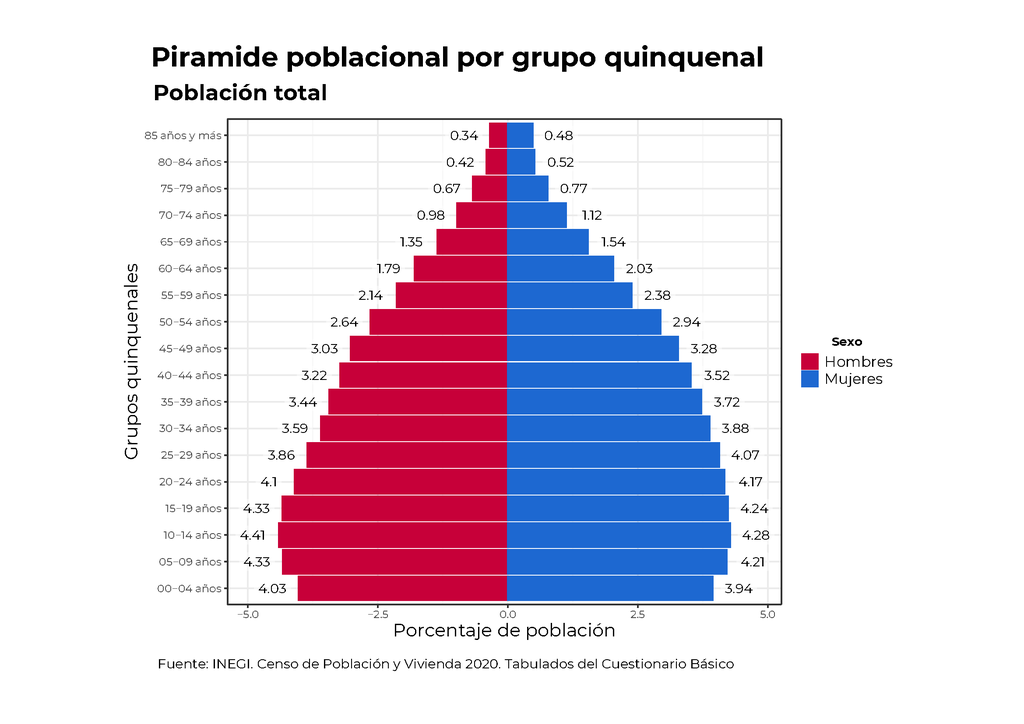

### Estructura de la población con discapacidad, con limitación en la actividad cotidiana o con algún problema o condición mental

De acuerdo con el Censo de Población y Vivienda 2020 del INEGI, la categoría “Población con discapacidad, con limitación en la actividad cotidiana o con algún problema o condición mental” agrupa a las personas que presentan alguna de las siguientes condiciones:

**Personas con discapacidad:** Aquellas que tienen dificultad para realizar actividades básicas de la vida diaria como ver, escuchar, caminar, recordar o concentrarse, vestirse, bañarse o comunicarse.

**Personas con limitación en la actividad cotidiana:** Individuos que, sin llegar a ser consideradas con discapacidad, presentan alguna dificultad para realizar actividades diarias como moverse, ver, escuchar, recordar, etc.

**Personas con algún problema o condición mental:** Aquellas que han sido diagnosticadas o que presentan alguna condición relacionada con la salud mental, como depresión, ansiedad, esquizofrenia, entre otras.

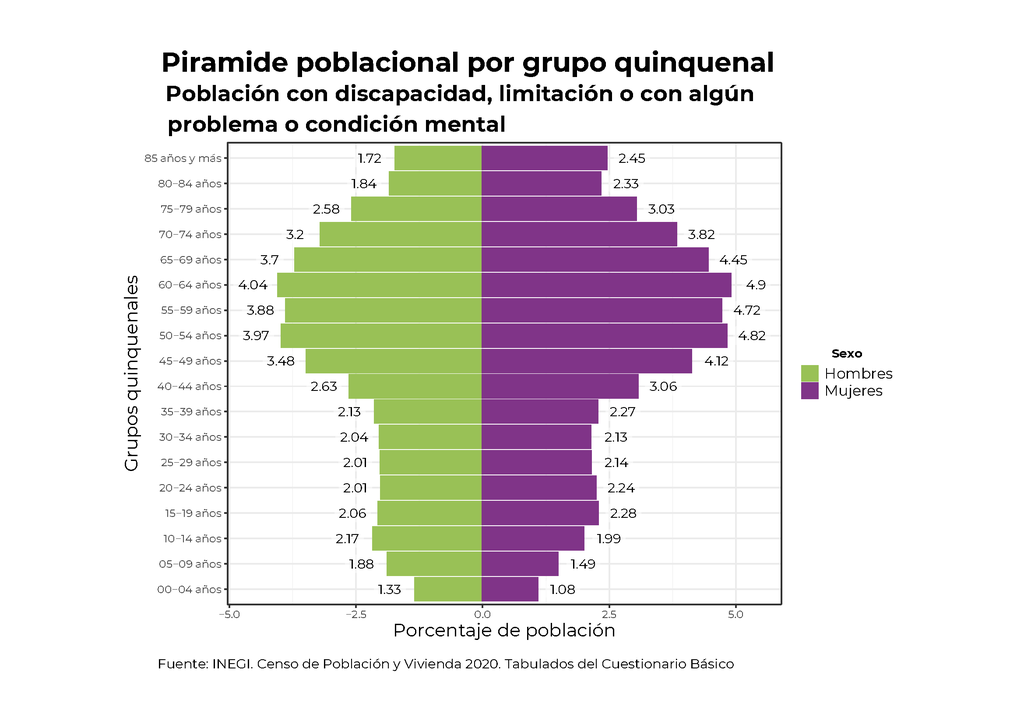

```r
require(ggplot2)
require(ggpubr)
require(Hmisc)
require(tidyverse)
require(tibble)
require(viridis)

paleta <- colorRampPalette(pals::kovesi.linear_blue_5_95_c73(2))(2)
paleta <- c("#99C156", "#803488")

tabla <- data %>%
          filter(Sexo %nin% "Total" & `Grupos quinquenales`%nin% c("Total", "No especificado")) %>%
           mutate(percent_POBTOT = case_when(Sexo %in% "Hombres" ~ .$`Población con discapacidad, limitación o con algún problema o condición mental`/ Totales["Población con discapacidad, limitación o con algún problema o condición mental",] * 100,
                                             Sexo %in% "Mujeres" ~ .$`Población con discapacidad, limitación o con algún problema o condición mental`/ Totales["Población con discapacidad, limitación o con algún problema o condición mental",] * 100)) %>%
            mutate(percent = ifelse(Sexo %in% "Hombres", -1 * .$percent_POBTOT, .$percent_POBTOT))

p <- tabla %>%
      ggplot(aes(x = percent,
                 y = `Grupos quinquenales`)) +
       geom_col(aes(color = Sexo, fill = Sexo)) +
        geom_smooth(color = "black", method = "loess", se = FALSE, show.legend = FALSE, size = 2) +
        geom_label(aes(x = ifelse(percent < 0, percent -0.5, percent + 0.5),
                   label = round(abs(percent), 2)),
                   fill = "white",
                   alpha = 0.5,
                   family = "Montserrat",
                   label.size = 0) +
         theme_bw() +
          theme(plot.title = element_text(size = 22, hjust = 0.15, family = "Montserrat", face = "bold"),
                plot.subtitle = element_text(size = 18, hjust = 0, family = "Montserrat", face = "bold"),
                plot.caption = element_text(size = 11, hjust = 0.2, vjust = 1, family = "Montserrat"),
                axis.text = element_text(family = "Montserrat"),
                axis.title = element_text(family = "Montserrat", size = 15),
                legend.key.size = unit(0.5, "cm"),
                legend.text = element_text(size = 12, family = "Montserrat"),
                legend.title = element_text(size = 10, hjust = 0.5, family = "Montserrat", face = "bold"),
                legend.position = "right"
               ) +
           scale_fill_manual(values = paleta) +
            scale_color_manual(values = paleta) +
             labs(title = "Piramide poblacional por grupo quinquenal",
                  subtitle = stringr::str_wrap("Población con discapacidad, limitación o con algún problema o condición mental", 50),
                  x = "Porcentaje de población",
                  fill = "Sexo",
                  color = "Sexo",
                  caption = expression(paste("Fuente: INEGI. Censo de Población y Vivienda 2020. Tabulados del Cuestionario Básico")))

p

#path = "Output/Piramide Población con discapacidad, limitación o con algún problema o condición mental.pdf"
#ggexport(p, filename = path ,width = 9, height = 7, device = "cairo")
```

**Nota.-** Incluye una estimación de población de 6 337 751 personas que corresponden a 1 588 422 viviendas sin información de ocupantes y menores omitidos.

**Nota.-**La suma de la población con discapacidad, limitación y con algún problema o condición mental es mayor, a la población total en dicha situación, por aquellas personas que tienen más de una discapacidad o limitación.

#### Distribución de la población con discapacidad, limitación o con algún problema o condición mental

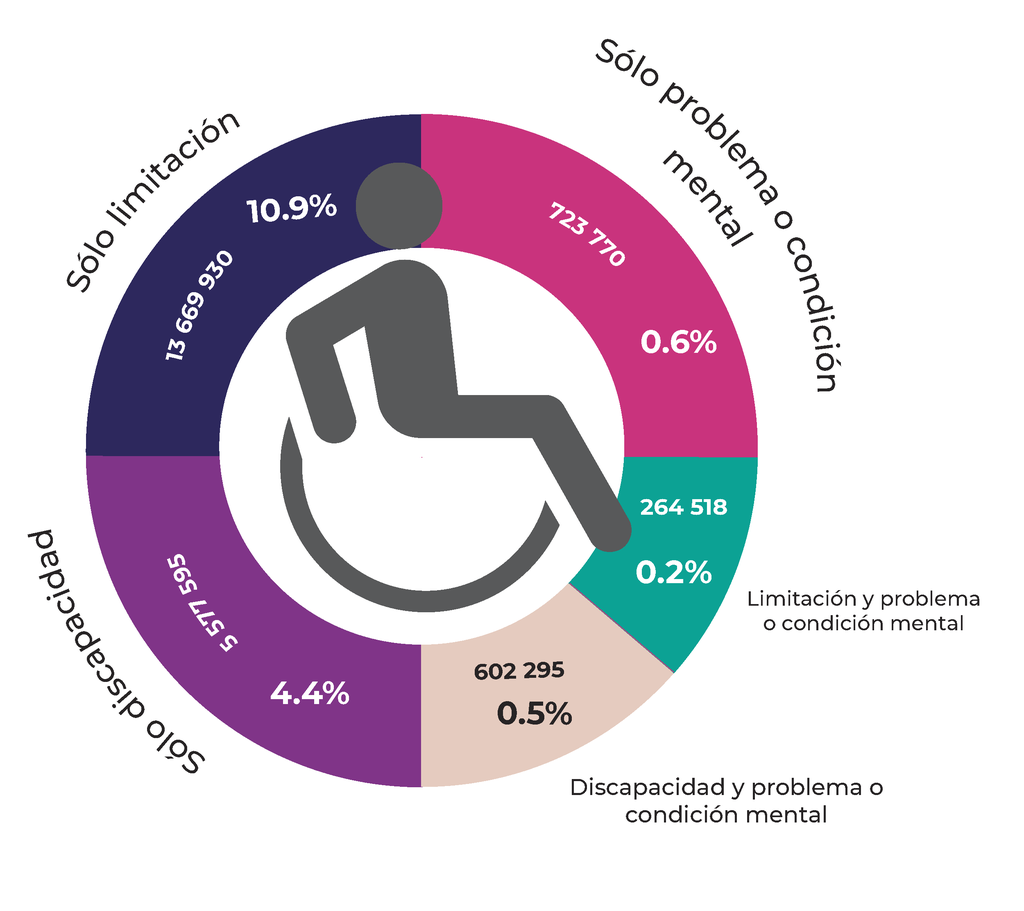

**Elaboración propia**

### Estructura de la población con discapacidad

[figure not shown]

```r
require(ggplot2)
require(ggpubr)
require(Hmisc)
require(tidyverse)
require(tibble)
require(viridis)

paleta <- colorRampPalette(pals::kovesi.linear_blue_5_95_c73(2))(2)
paleta <- c("#373C88", "#803488")

tabla <- data %>%
          filter(Sexo %nin% "Total" & `Grupos quinquenales`%nin% c("Total", "No especificado")) %>%
           mutate(percent_POBTOT = case_when(Sexo %in% "Hombres" ~ .$`Con discapacidad (Total)`/ Totales["Con discapacidad (Total)",] * 100,
                                             Sexo %in% "Mujeres" ~ .$`Con discapacidad (Total)`/ Totales["Con discapacidad (Total)",] * 100)) %>%
            mutate(percent = ifelse(Sexo %in% "Hombres", -1 * .$percent_POBTOT, .$percent_POBTOT))

p <- tabla %>%
      ggplot(aes(x = percent,
                 y = `Grupos quinquenales`)) +
       geom_col(aes(color = Sexo, fill = Sexo)) +
        geom_smooth(color = "black", method = "loess", se = FALSE, show.legend = FALSE, size = 2) +
        geom_label(aes(x = ifelse(percent < 0, percent -0.5, percent + 0.5),
                   label = round(abs(percent), 2)),
                   fill = "white",
                   alpha = 0.5,
                   family = "Montserrat",
                   label.size = 0) +
         theme_bw() +
          theme(plot.title = element_text(size = 22, hjust = 0.15, family = "Montserrat", face = "bold"),
                plot.subtitle = element_text(size = 18, hjust = 0, family = "Montserrat", face = "bold"),
                plot.caption = element_text(size = 11, hjust = 0.2, vjust = 1, family = "Montserrat"),
                axis.text = element_text(family = "Montserrat"),
                axis.title = element_text(family = "Montserrat", size = 15),
                legend.key.size = unit(0.5, "cm"),
                legend.text = element_text(size = 12, family = "Montserrat"),
                legend.title = element_text(size = 10, hjust = 0.5, family = "Montserrat", face = "bold"),
                legend.position = "right"
               ) +
           scale_fill_manual(values = paleta) +
            scale_color_manual(values = paleta) +
             labs(title = "Estructura de la población con discapacidad",
                  subtitle = stringr::str_wrap("Población con discapacidad", 50),
                  x = "Porcentaje de población",
                  fill = "Sexo",
                  color = "Sexo",
                  caption = expression(paste("Fuente: INEGI. Censo de Población y Vivienda 2020. Tabulados del Cuestionario Básico")))

p

path = "Output/Piramide Población con discapacidad.pdf"
ggexport(p, filename = path ,width = 9, height = 7, device = "cairo")
```

[figure not shown]

De acuerdo al Censo de Población y Vivienda, un **total de 6 179 890 personas** han reportado tener algún tipo de discapacidad. Estas personas experimentan diferentes grados de dificultad en la realización de actividades cotidianas. Las estadísticas indican que el 47.6% presenta dificultades para la movilidad (caminar, subir o bajar), el 43.5% tiene dificultades visuales incluso utilizando lentes correctivos, el 21.9% experimenta dificultades auditivas aun con aparatos auxiliares, el 18.9% requiere asistencia para actividades de autocuidado (baño, vestimenta o alimentación), el 18.6% presenta dificultades cognitivas (memoria o concentración), y el 15.3% enfrenta desafíos en la comunicación oral. Es importante señalar que estos porcentajes pueden sumar más del 100% debido a que algunas personas presentan múltiples tipos de discapacidad.

**Elaboración propia**

#### Distribución de la población con discapacidad por grupos de edad

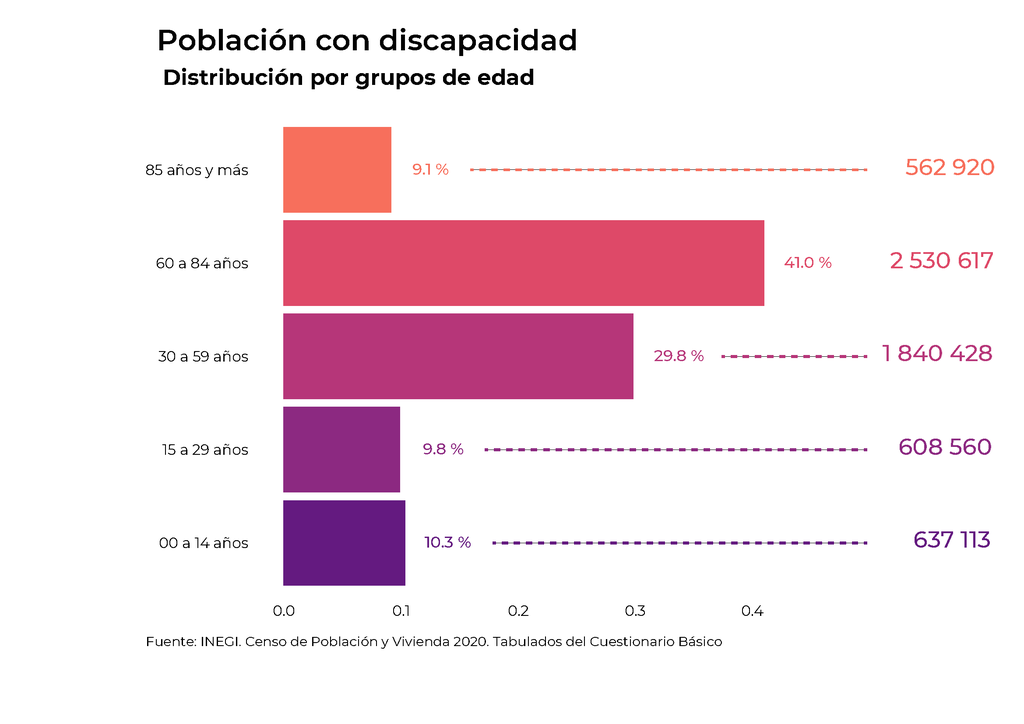

```r
tabla <- data %>%
          mutate(Grupos = case_when(`Grupos quinquenales` %in% c("00-04 años", "05-09 años", "10-14 años") ~ "00 a 14 años",
                                    `Grupos quinquenales` %in% c("15-19 años", "20-24 años", "25-29 años") ~ "15 a 29 años",
                                    `Grupos quinquenales` %in% c("30-34 años", "35-39 años", "40-44 años", "45-49 años", "50-54 años", "55-59 años") ~ "30 a 59 años",
                                    `Grupos quinquenales` %in% c("60-64 años", "65-69 años", "70-74 años", "75-79 años", "80-84 años") ~ "60 a 84 años",
                                    `Grupos quinquenales` %in% c("85 años y más") ~ "85 años y más")) %>%
           filter(Sexo %in% "Total") %>%
            filter(`Grupos quinquenales` %nin% c("Total", "No especificado")) %>%
             group_by(Grupos) %>%
              summarise(Pob_Total = sum(`Con discapacidad (Total)`)) %>%
               janitor::adorn_percentages(denominator = "col")


p <- tabla %>%
      ggplot() +
       geom_col(aes(x = Pob_Total, y = Grupos, color = Grupos, fill = Grupos)) +
        geom_text(aes(x = Pob_Total, y = Grupos, color = Grupos,
                  label = paste(format(Pob_Total * 100, digits = 2), "%")),
                  hjust = -0.5,
                  fontface = "bold",
                  family = "Montserrat Medium") +
        theme_transparent() +
          theme(plot.title = element_text(size = 22, hjust = 0, family = "Montserrat SemiBold", face = "bold"),
                plot.subtitle = element_text(size = 18, hjust = 0, family = "Montserrat", face = "bold"),
                plot.caption = element_text(size = 11, hjust = 0.2, vjust = 1, family = "Montserrat"),
                axis.text = element_text(family = "Montserrat"),
                axis.title = element_text(family = "Montserrat", size = 15),
                legend.key.size = unit(0.5, "cm"),
                legend.text = element_text(size = 12, family = "Montserrat"),
                legend.title = element_text(size = 10, hjust = 0.5, family = "Montserrat", face = "bold"),
                legend.position = "none"
               ) +
           scale_fill_viridis_d(option = "A", begin = 0.3, end = 0.7) +
            scale_color_viridis_d(option = "A", begin = 0.3, end = 0.7) +
             xlim(c(0, 0.5)) +
              labs(title = "Población con discapacidad",
                   subtitle = stringr::str_wrap("Distribución por grupos de edad", 50),
                   x = "",
                   y = "",
                   caption = expression(paste("Fuente: INEGI. Censo de Población y Vivienda 2020. Tabulados del Cuestionario Básico")))
p

#path = "Output/Piramide Población con discapacidad_Grupos de edad.pdf"
#ggexport(p, filename = path ,width = 9, height = 7, device = "cairo")
```

La distribución por grupos etarios muestra que casi el 71% de la población con discapacidad se encuentran entre los 30 a los 84 años de edad.

#### Distribución de la población con discapacidad por estados

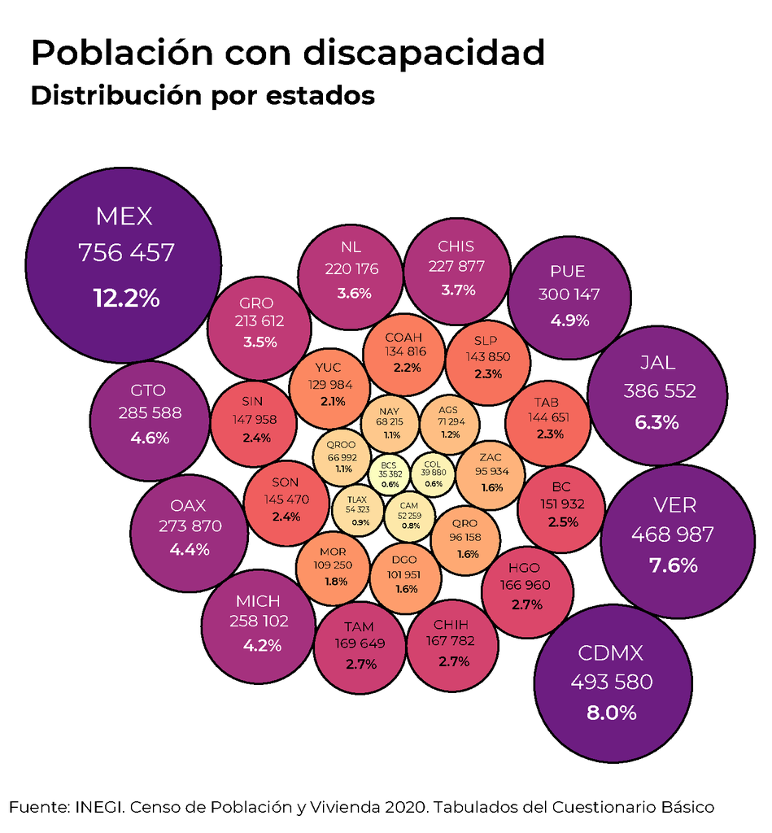

```r
require(packcircles)

tabla <- mydata %>%
          mutate(Entidad = case_when(`Entidad Federativa` %in% "01 Aguascalientes" ~ "AGS",
                                     `Entidad Federativa` %in% "02 Baja California" ~ "BC",
                                     `Entidad Federativa` %in% "03 Baja California Sur" ~ "BCS",
                                     `Entidad Federativa` %in% "04 Campeche" ~ "CAM",
                                     `Entidad Federativa` %in% "05 Coahuila de Zaragoza" ~ "COAH",
                                     `Entidad Federativa` %in% "06 Colima" ~ "COL",
                                     `Entidad Federativa` %in% "07 Chiapas" ~ "CHIS",
                                     `Entidad Federativa` %in% "08 Chihuahua" ~ "CHIH",
                                     `Entidad Federativa` %in% "09 Ciudad de México" ~ "CDMX",
                                     `Entidad Federativa` %in% "10 Durango" ~ "DGO",
                                     `Entidad Federativa` %in% "11 Guanajuato" ~ "GTO",
                                     `Entidad Federativa` %in% "12 Guerrero" ~ "GRO",
                                     `Entidad Federativa` %in% "13 Hidalgo" ~ "HGO",
                                     `Entidad Federativa` %in% "14 Jalisco" ~ "JAL",
                                     `Entidad Federativa` %in% "15 México" ~ "MEX",
                                     `Entidad Federativa` %in% "16 Michoacán de Ocampo" ~ "MICH",
                                     `Entidad Federativa` %in% "17 Morelos" ~ "MOR",
                                     `Entidad Federativa` %in% "18 Nayarit" ~ "NAY",
                                     `Entidad Federativa` %in% "19 Nuevo León" ~ "NL",
                                     `Entidad Federativa` %in% "20 Oaxaca" ~ "OAX",
                                     `Entidad Federativa` %in% "21 Puebla" ~ "PUE",
                                     `Entidad Federativa` %in% "22 Querétaro" ~ "QRO",
                                     `Entidad Federativa` %in% "23 Quintana Roo" ~ "QROO",
                                     `Entidad Federativa` %in% "24 San Luis Potosí" ~ "SLP",
                                     `Entidad Federativa` %in% "25 Sinaloa" ~ "SIN",
                                     `Entidad Federativa` %in% "26 Sonora" ~ "SON",
                                     `Entidad Federativa` %in% "27 Tabasco" ~ "TAB",
                                     `Entidad Federativa` %in% "28 Tamaulipas" ~ "TAM",
                                     `Entidad Federativa` %in% "29 Tlaxcala" ~ "TLAX",
                                     `Entidad Federativa` %in% "30 Veracruz de Ignacio de la Llave" ~ "VER",
                                     `Entidad Federativa` %in% "31 Yucatán" ~ "YUC",
                                     `Entidad Federativa` %in% "32 Zacatecas" ~ "ZAC")) %>%
           filter(Sexo %in% "Total") %>%
            filter(`Entidad Federativa` %nin% "Estados Unidos Mexicanos") %>%
             filter(`Grupos quinquenales` %nin% c("Total", "No especificado")) %>%
              group_by(`Entidad`) %>%
               summarise(Pob_Total = sum(`Con discapacidad (Total)`)) %>%
                 arrange(Pob_Total) %>%
                  mutate(radius = circleProgressiveLayout(.$Pob_Total, sizetype='area'))
color_text <- c(rep("black", 18), rep("white", 14))

packing <- circleProgressiveLayout(tabla$Pob_Total, sizetype='area')
dat.gg <- circleLayoutVertices(packing, npoints=50)


p <- ggplot() +
     geom_polygon(data = dat.gg,
                  aes(x, y, group = id, fill = as.factor(id)),
                  colour = "black",
                  alpha = 1) +
     geom_text(data = tabla,
                aes(x = radius$x,
                    y = radius$y,
                    size = Pob_Total,
                    label = paste(Entidad, "\n", format(Pob_Total, big.mark = " "))),
                color = color_text,
                family = "Montserrat") +
       theme_void() +
        theme(plot.title = element_text(size = 22, hjust = 0, family = "Montserrat SemiBold", face = "bold"),
              plot.subtitle = element_text(size = 18, hjust = 0, family = "Montserrat", face = "bold"),
              plot.caption = element_text(size = 11, hjust = 0.2, vjust = 1, family = "Montserrat"),
              axis.text = element_blank(),
              axis.title = element_blank(),
              legend.key.size = unit(0.5, "cm"),
              legend.text = element_text(size = 12, family = "Montserrat"),
              legend.title = element_text(size = 10, hjust = 0.5, family = "Montserrat", face = "bold"),
              legend.position = "none"
               ) +
         scale_size_continuous(range = c(1,6)) +
          scale_fill_viridis_d(option = "A", begin = 0.3, end = 1, direction = -1) +
           scale_color_viridis_d(option = "A", begin = 0.3, end = 1, direction = -1) +
            coord_equal()  +
             labs(title = "Población con discapacidad",
                  subtitle = stringr::str_wrap("Distribución por estados", 50),
                   x = "",
                   y = "",
                   caption = expression(paste("Fuente: INEGI. Censo de Población y Vivienda 2020. Tabulados del Cuestionario Básico")))

require(plotly)
plotly::ggplotly(p)
#path = "Output/Población con discapacidad_Estados.pdf"
#ggexport(p, filename = path ,width = 9, height = 7, device = "cairo")
```

Las entidades que concentran mayor población con discapacidad son México, Ciudad de México, Veracruz y Jalisco.

## Referencias

Instituto Nacional de Estadística y Geografía [INEGI], 2017, La discapacidad en México, datos al 2014. Versión 2017, disponible en https://www.inegi.org.mx/contenidos/productos/prod_serv/contenidos/espanol/bvinegi/productos/nueva_estruc/702825094409.pdf

Instituto Nacional de Estadística y Geografía. (2020). Censo de Población y Vivienda 2020: Base de datos y resultados definitivos. INEGI. https://www.inegi.org.mx/programas/ccpv/2020/

This work by **Diana Villasana Ocampo** is licensed under a [Creative Commons Attribution 4.0 International License](http://creativecommons.org/licenses/by/4.0/).